# relaciones_internacionales_en_espanha

## < < Volver al Índice

Relaciones Internacionales en España

[Brais Seara Martínez @ github.com/braisseara/blog](https://github.com/braisseara/blog)

En esta entrada continuamos trabajando con la **Estadística de Nacimientos** que elabora cada año el Instituto Nacional de Estadística (INE), pero esta vez prestando atención al **país** de procedencia de los padres.

[I] Setup

En este apartado cargamos todos los datos que vamos a usar. Los microdatos serán los mismos archivos que cargamos en el análisis provincial, y los Metadatos son en este caso diferentes.

# Descarga de los Ficheros de Nacimientos

Descargamos los ficheros de Nacimientos correspondientes a los años que queremos analizar, en la siguiente dirección del INE:

http://www.ine.es/dyngs/INEbase/es/operacion.htm?c=Estadistica_C&cid=1254736177007&menu=resultados&secc=1254736195443&idp=1254735573002

Solamente nos descargamos los ficheros posteriores a 2007, porque los de años anteriores involucran metodologías heterogéneas.

En nuestro directorio de trabajo los almacenamos en la carpeta **../../datos/relaciones_internacionales_en_espanha**, separando por un lado los ficheros de **microdatos** propios de cada año, de los **metadatos** que vienen con cada uno de ellos, y que son iguales para todos.

Tenemos además otra carpeta con todos los metadatos que hemos traído de otras fuentes, ubicada en **externos**

### Estructura de Carpetas de Datos

- ../../datos/relaciones_internacionales_en_espanha
  - microdatos
    - 2007.txt
    - 2011.txt
    - 2014.txt
    - 2017.txt
  - metadatos
    - Diseñoanonimizadonacimientos.xls
    - Valores válidosDiseñoanonimizadonacimientos.xls
    - externos
      - iso3_region_incomegroup_country.csv
      - iso3_counstrywho.csv
      - pais_iso3_region_grupoingresos.csv
      - iso3_gdppc.csv
    - mapa

# Imports

```python
import pandas
import numpy as np
import seaborn as sns
import matplotlib as pyplot
import matplotlib.pyplot as plt
import geopandas as gpd
import math
from collections import Counter
import warnings
warnings.filterwarnings('ignore')
# + tener mapclassify instalado

# Con esto conseguimos tener figuras de DataFrames uno al lado del otro y no debajo:
from IPython.display import display, HTML
CSS = """
.output {
    flex-direction: row;
}
"""
HTML('<style>{}</style>'.format(CSS))
```

Con esto conseguimos que las imagenes se muestren completas sin scrollbar:

```python
%%javascript
IPython.OutputArea.prototype._should_scroll = function(lines) {
    return false;
}
```

# Config

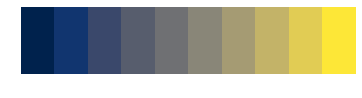

```python
colormap = "cividis" #"OrRd"

plt.axis('off')
a = plt.imshow([[i for i in range(0,10)],[i for i in range(0,10)]], cmap = colormap)
```

En esta paleta vemos una muestra del mapa de color que usaremos para representar visualmente las cantidades en diagramas y mapas. Cuanto más amarillo, más cantidad (que en esta entrada se tenderá a relacionar con un mayor grado de "relaciones internacionales"). En cambio, cuanto más azul, menos cantidad.

# Metadatos

### INE.Nacimientos

El INE nos proporciona 2 ficheros excel de metadatos para los Nacimientos a partir del 2007:

- *Diseñoanonimizadonacimientos.xls*
- *Valores válidosDiseñoanonimizadonacimientos.xls*

Lo único que ahora nos interesa de ellos son 3 columnas del primero, que nos indican la Longitud fija que ocupan los registros de cada columna de microdatos, sus Nombres, y la Descripción de lo que representan.

```python
ruta_datos = "../../datos/relaciones_internacionales_en_espanha/"
```

```python
metadatos_ine = pandas.read_excel(ruta_datos + "metadatos/Diseñoanonimizadonacimientos.xls", 0)
metadatos_ine = metadatos_ine[['Longitud','Nombre','Descripción']]
```

```python
metadatos_ine.head()
```

|  | Longitud | Nombre | Descripción |
| --- | --- | --- | --- |
| 0 | 2 | PROI | PROVINCIA DE INSCRIPCIÓN |
| 1 | 3 | MUNI | MUNICIPIO DE INSCRIPCIÓN |
| 2 | 2 | MESPAR | MES DEL PARTO |
| 3 | 4 | ANOPAR | AÑO DEL PARTO |
| 4 | 2 | PROPAR | PROVINCIA DEL PARTO |

### Externos

Los metadatos que nos proporciona el INE en los mismos ficheros de Nacimientos son insuficientes, ya que los países están representadas según un código ISO3, por lo que hemos obtenido un mapping que nos da los nombres reales de los países a partir de su código. Además, a partir de las estadísticas económicas del Banco Mundial, obtenemos el PIB per Cápita de cada país.

```python
ISO3_Region_Country = pandas.read_csv(ruta_datos + "metadatos/externos/iso3_region_incomegroup_country.csv")
ISO3_Region_Country = ISO3_Region_Country[["TableName","Region","Country Code"]].dropna()
ISO3_Region_Country.columns = ["Country","Region","ISO3"]
ISO3_Region_Country=ISO3_Region_Country.set_index("ISO3")

ISO3_Country_WHO = pandas.read_csv(ruta_datos + "metadatos/externos/iso3_counstrywho.csv", header=None)[[1,2]]
ISO3_Country_WHO.columns = ["ISO3","CountryWHO"]
ISO3_Country_WHO=ISO3_Country_WHO.set_index("ISO3")

INE_ISO3=pandas.read_csv(ruta_datos+"metadatos/externos/codigoine_iso3.txt",sep='\t',header=None,encoding='iso8859_3')[[0,2]]
INE_ISO3.columns = ["CodidoINE","ISO3"]
INE_ISO3=INE_ISO3.set_index("ISO3")

ISO3_Pais = pandas.read_csv(ruta_datos+"metadatos/externos/pais_iso3_region_grupoingresos.csv")[["Country Code","Country Name"]]
ISO3_Pais.columns = ["ISO3","Pais"]
ISO3_Pais = ISO3_Pais.dropna()
ISO3_Pais=ISO3_Pais.set_index("ISO3")

pib_pp = pandas.read_csv(ruta_datos + "metadatos/externos/iso3_gdppc.csv", header = 2)
pib_pp = pib_pp[['Country Code','2017']]
pib_pp.columns = ['ISO3','ppc']
pib_pp = pib_pp[np.isfinite(pib_pp['ppc'])]
pib_pp=pib_pp.set_index("ISO3")

metadatos_paises = ISO3_Region_Country.join(ISO3_Country_WHO).join(ISO3_Pais).join(pib_pp).join(INE_ISO3).dropna()

metadatos_paises['ppc'] = metadatos_paises['ppc'].apply(lambda x : int(round(x,0)))
metadatos_paises['CodidoINE'] = metadatos_paises['CodidoINE'].apply(lambda x : int(round(x,0)))
metadatos_paises.head()
```

| ISO3 | Country | Region | CountryWHO | Pais | ppc | CodidoINE |
| --- | --- | --- | --- | --- | --- | --- |
| ABW | Aruba | Latin America & Caribbean | Aruba | Aruba | 25655 | 386 |
| AFG | Afghanistan | South Asia | Afghanistan | Afganistán | 550 | 401 |
| AGO | Angola | Sub-Saharan Africa | Angola | Angola | 4100 | 202 |
| ALB | Albania | Europe & Central Asia | Albania | Albania | 4538 | 101 |
| AND | Andorra | Europe & Central Asia | Andorra | Andorra | 39147 | 124 |

Creamos diccionarios que nos permitan acceder a algunos de estos metadatos facilmente:

```python
dict_ISO3_Country = pandas.Series(metadatos_paises.Country.values,index=metadatos_paises.index).to_dict()
dict_Country_ISO3 = pandas.Series(metadatos_paises.index,index=metadatos_paises.Country).to_dict()
dict_ISO3_Country_WHO =  pandas.Series(metadatos_paises.index,index=metadatos_paises.Country).to_dict()
dict_ISO3_Region  = pandas.Series(metadatos_paises.Region.values,index=metadatos_paises.index).to_dict()
dict_INE_ISO3 = pandas.Series(metadatos_paises.index,index=metadatos_paises.CodidoINE).to_dict()
```

# Mapa

Cargamos el mapa del mundo en formato *shape* que usaremos más adelante

```python
map_df = gpd.read_file(ruta_datos + "shape_map_world/TM_WORLD_BORDERS_SIMPL-0.3.shp")
map_df.index = map_df["ISO3"]
```

# Países Agrupados y Ordenados

Con estos datos podemos crear una lista ordenada de países que ordenaremos según su PIB per Cápita

```python
paises_ordenados = pandas.Series(metadatos_paises.sort_values(['ppc'], ascending = False).index)
paises_ordenados[0:10]
```

```
0    LUX
1    MAC
2    CHE
3    NOR
4    ISL
5    IRL
6    QAT
7    USA
8    SGP
9    DNK
Name: ISO3, dtype: object
```

```python
dict_paises_ordenados = {pais[2]: pais[0] for pais in paises_ordenados.reset_index().itertuples()}

print("España" + ' va de ' + str(dict_paises_ordenados["ESP"]+1) + 'º')
```

```
España va de 34º
```

# Lectura Microdatos

```python
años = [2017]

ruta_microdatos = ruta_datos + "microdatos/"

if not "DFs_" in vars():
    DFs_ = {}
DFs  = {}
for año in años:
    try:
        DFs[año] = DFs_[año].copy()
    except KeyError:
        DFs_[año] = pandas.read_fwf(ruta_microdatos + str(año) + ".txt", widths= metadatos_ine['Longitud'])
        DFs[año] = DFs_[año].copy()
```

```python
for key in list(DFs.keys()):
    # nombramos columnas
    DFs[key].columns = metadatos_ine['Nombre']
    # nos quedamos con las columnas que nos interesan
    DFs[key] =  DFs[key][['PAISNACM','PAISNACP']]  # prov. nacimiento madre, prov. nacimiento padre y prov. nacimiento niñ@
    # eliminamos filas con valores nulos
    DFs[key] =  DFs[key][np.isfinite( DFs[key]['PAISNACM'])]
    DFs[key] =  DFs[key][np.isfinite( DFs[key]['PAISNACP'])]
    # substituímos los códigos de los países por sus nombres
    DFs[key] = DFs[key].replace({'PAISNACM':dict_INE_ISO3})
    DFs[key] = DFs[key].replace({'PAISNACP':dict_INE_ISO3})
```

```python
DFs[año].head()
```

| Nombre | PAISNACM | PAISNACP |
| --- | --- | --- |
| 771 | MAR | BEL |
| 772 | MAR | MAR |
| 784 | AUT | AUT |
| 785 | MEX | AUT |
| 786 | BEL | BEL |

[II] Conteo Nacidos por País de Origen de los Padres

A continuación, procedemos a elaborar una matriz que recoja el número de nacidos para cada combinación de origines nacionales de los padres

```python
def get_matrices(minimo_hijos = 0):

    matrices = {}

    for key in list(DFs.keys()):

        # crear matriz de ceros
        matrices[key] = []
        for i in range(0,len(paises_ordenados)):
            matrices[key].append([])
            for j in range(0,len(paises_ordenados)):
                matrices[key][i].append(0)

        # rellenar matriz
        for nac in DFs[key].itertuples():
            try:
                matrices[key][dict_paises_ordenados[nac[1]]][dict_paises_ordenados[nac[2]]] += 1
            except KeyError:
                continue

        # etiquetar matriz
        matrices[key] = pandas.DataFrame(matrices[key])
        matrices[key].columns= paises_ordenados
        matrices[key].index = paises_ordenados

    for key in list(DFs.keys()):

        # restringir matriz
        booleanos = list((matrices[key].sum(1) + matrices[key].sum(0))/2 > minimo_hijos)
        paises_significativos = pandas.Series(list(matrices[key].index)).loc[booleanos]
        matrices[key] = matrices[key].loc[paises_significativos, paises_significativos]

    return(matrices)
```

```python
matrices = get_matrices(200)
```

```python
matrices[año].loc["ESP"].loc[~matrices[año].loc["ESP"].index.isin(['ESP'])].sum()
```

```
15504
```

Este es el número de mujeres españolas que han tenido hijos con hombres extranjeros en España

```python
matrices[año].loc[:,"ESP"].loc[~matrices[año].loc["ESP"].index.isin(['ESP'])].sum()
```

```
19823
```

Y este es el número de hombres españoles que han tenido hijos con mujeres extranjeras en España

Esta asimetría la notaremos en algunos de los análisis posteriores en los que intentamos aproximar las "relaciones internacionales" en España, entendiendo por ello la magnitud de las relaciones entre diversas combinaciones de nacionalidades y sexos a partir de sus resultados reproductivos. Sin embargo, hay que tener en cuenta que posiblemente las mujeres de las nacionalidades con las que más se relacionan los hombres españoles proceden de países y culturas más natalistas de lo que lo son las mujeres españolas.

Dado que existen grandes diferencias en el número de nacidos con cada combinación de nacionalidades de los padres, al haber nacionalidades con un número de individuos en España mucho mayor que el de otras, podemos considerar aplicar a las visualizaciones una función de suavizado logarítmico, de modo que podamos ver más de lo que es algo menos importante, pero sin perder en ningun caso el orden de prelación

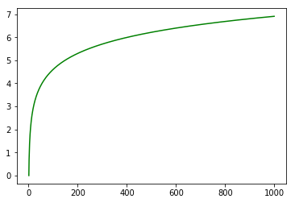

```python
a = np.arange(1,1000,1)
b = [math.log(i) for i in a ]
_ = plt.plot(a, b, color = "g")
```

Ilustración del efecto suavizador que produce la función logarítmica

### Función de representación gráfica de matrices:

(con opción de suavizado logarítmico)

```python
def plot_matriz(matriz, titulo = 'Matriz', suavizado_logaritmico = False, times_sl = 1, anular_diagonal = False, regions=False):
    matriz = matriz.copy()
    paises = list(matriz.index)
    n = len(paises)
    if anular_diagonal == True:
        for i in range(0,n):
            matriz.iloc[i,i] = min(matriz.min())
    if suavizado_logaritmico == True:
        for time in range(0,times_sl):
            matriz = matriz.applymap(lambda celda : math.log(max(0,celda) + 1) )
    fig, ax = plt.subplots(1, figsize=(13, 13))
    plt.imshow(matriz, cmap = colormap, aspect='auto')
    ax.set_yticks(np.arange(n))
    ax.set_yticklabels(paises)
    ax.set_xticks(np.arange(n))
    ax.set_xticklabels(paises, rotation=70)
    ax.set_title(titulo, fontdict = {'fontsize': 30,'fontweight':500}, pad =30)
    ax.set_xlabel('padre',fontweight='bold',fontsize=20, labelpad = 10)
    ax.set_ylabel('madre',fontweight='bold',fontsize=20, labelpad = 10)

    if regions == True:
        ps = pandas.Series(provincias).reset_index()
        ps.columns = ['i', 'Pais']
        ccaa_n = ps.join(metadatos_paises.set_index('Pais'), how = 'left', on = 'Pais')['Region']
        ccaa_n = list(pandas.DataFrame.from_dict(Counter(ccaa_n), orient='index').iloc[:,0].cumsum().apply(lambda i: i-0.5))

        ax.set_yticks(ccaa_n, minor = True)
        ax.set_xticks(ccaa_n, minor = True)
        ax.grid(which='minor', alpha=1, linewidth = 1.2, linestyle=':', color = 'black')
```

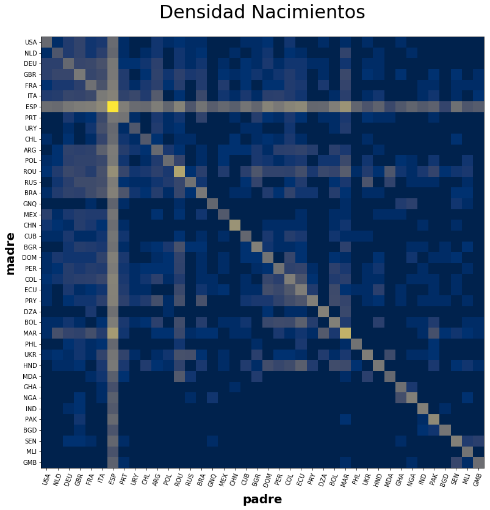

```python
plot_matriz(matrices[año], "Densidad Nacimientos", True)
```

En este gráfico suavizado Vamos a crear una función para obtener facilmente las primeras (o ultimas) posiciones del ranking en matrices de este tipo

### Función de Rankings:

```python
def top_matriz(matriz,top=10,que='max',x='values',madres=None,padres=None,funcion_values=lambda x:round(x, 2),c='',sty = 'on'):
    madre = []
    padre = []
    values = []
    if madres == None:
        madres = list(matriz.columns)
    else:
        if isinstance(madres, str):
            madres = [madres]
    if padres == None:
        padres = list(matriz.columns)
    else:
        if isinstance(padres, str):
            padres = [padres]
    for i in madres:
        for j in padres:
            madre.append(i)
            padre.append(j)
            values.append(matriz.loc[i,j])
    df = pandas.DataFrame({'madre': madre, 'padre': padre, x: values}).sort_values([x], ascending = (que == 'min') )
    df.index = [str(i + 1) + 'º' for i in df.reset_index().index]
    if isinstance(funcion_values, str):
        if funcion_values == 'delta%':
            funcion_values = lambda x : '+ ' + str(round((x-1)*100,2)) + ' %'
        elif funcion_values == 'delta':
            funcion_values = lambda x : '+ ' + str(round(x,2))
        elif funcion_values == '%':
            funcion_values = lambda x : str(round(x*100,2)) + ' %'
        elif funcion_values == 'delta%num':
            funcion_values = lambda x : round(x*100,2)
    df[x] = df[x].apply(funcion_values)
    if isinstance(top, str):
        top = matriz.shape[0]
    if sty == 'on':
        return(df.head(top).style.set_caption(c))
    else:
        return(df.head(top))
```

```python
top_matriz(matrices[año], top = 15, x = 'nacimientos', c = 'Países con más hijos')
```

Países con más hijos

|  | madre | padre | nacimientos |
| --- | --- | --- | --- |
| 1º | ESP | ESP | 291046 |
| 2º | MAR | MAR | 17198 |
| 3º | ROU | ROU | 7744 |
| 4º | MAR | ESP | 4272 |
| 5º | ESP | MAR | 2684 |
| 6º | CHN | CHN | 2569 |
| 7º | ROU | ESP | 1955 |
| 8º | PAK | PAK | 1445 |
| 9º | ESP | ITA | 1376 |
| 10º | ESP | ECU | 1346 |
| 11º | COL | ESP | 986 |
| 12º | ESP | COL | 975 |
| 13º | ESP | DOM | 969 |
| 14º | ESP | ROU | 919 |
| 15º | ITA | ESP | 873 |

[III] Nuevas chicas Rusas buscan esposo en tu Ciudad

En este apartado analizamos los rumores de que, por ejemplo, existan más Rusas teniendo hijos con Españoles que Rusos teniendo hijos con Españolas

```python
matriz_sexo_diferencial = matrices[año].copy()
n = matrices[año].shape[0]
umbral = n/2
for i in range(0,n):
    for j in range(0,n):
        matriz_sexo_diferencial.iloc[i,j] =  matrices[año].iloc[i,j] - matrices[año].iloc[j,i]
```

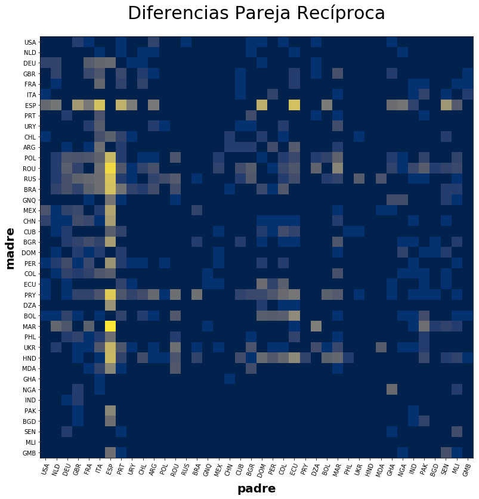

```python
plot_matriz(matriz_sexo_diferencial, 'Diferencias Pareja Recíproca', True)
```

En esta matriz la intensidad del color amarillo indica que esa pareja es más frecuente que su recíproca.

```python
matriz_sexo_diferencial = matrices[año].copy()
n = matrices[año].shape[0]
minimo_significativo = 20
for i in range(0,n):
    for j in range(0,n):
        if matrices[año].iloc[i,j] > minimo_significativo and matrices[año].iloc[j,i] > minimo_significativo:
            matriz_sexo_diferencial.iloc[i,j] = matrices[año].iloc[i,j] / max(matrices[año].iloc[j,i], 1)
        else:
            matriz_sexo_diferencial.iloc[i,j] = 1
```

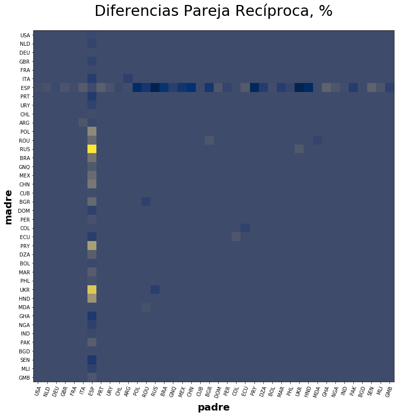

```python
plot_matriz(matriz_sexo_diferencial, 'Diferencias Pareja Recíproca, %', True)
```

Esta matriz es equivalente a la anterior, solo que la frecuencia de una pareja reproductiva respecto a su recíproca nacional se expresa en términos porcentuales, por lo que ahora podemos comparar estas anomalías entre diferentes países sin importarnos el peso demográfico de cada uno en España

```python
top_matriz(matriz_sexo_diferencial, top = 10, x ='respecto a viceversa', padres ='ESP', funcion_values ='delta%')
```

|  | madre | padre | respecto a viceversa |
| --- | --- | --- | --- |
| 1º | RUS | ESP | + 1375.0 % |
| 2º | UKR | ESP | + 922.22 % |
| 3º | PRY | ESP | + 463.38 % |
| 4º | HND | ESP | + 381.82 % |
| 5º | POL | ESP | + 296.8 % |
| 6º | CHN | ESP | + 185.53 % |
| 7º | BRA | ESP | + 156.63 % |
| 8º | MEX | ESP | + 128.28 % |
| 9º | BGR | ESP | + 114.39 % |
| 10º | ROU | ESP | + 112.73 % |

```python
top_matriz(matriz_sexo_diferencial, x ='respecto a viceversa', madres ='ESP', funcion_values ='delta%')
```

|  | madre | padre | respecto a viceversa |
| --- | --- | --- | --- |
| 1º | ESP | GHA | + 88.0 % |
| 2º | ESP | SEN | + 87.41 % |
| 3º | ESP | PRT | + 72.01 % |
| 4º | ESP | ITA | + 57.62 % |
| 5º | ESP | ECU | + 54.54 % |
| 6º | ESP | NGA | + 39.74 % |
| 7º | ESP | DOM | + 37.84 % |
| 8º | ESP | MLI | + 32.26 % |
| 9º | ESP | GBR | + 27.73 % |
| 10º | ESP | URY | + 27.52 % |

¿Y de qué países proceden los hombres que atraen más a las mujeres españolas respecto al caso "viceversa"? Los dos primeros puestos son para dos países africanos: Ghana y Senegal. Un factor que podría explicar parte de este fenómeno sería la posibilidad de que sean más los varones que migran a España desde estos países. Los siguientes en la lista son: Portugal, Italia, Ecuador, Nigeria, República Dominicana, Mali, Reino Unido y Uruguay. En total, pues, son 4 los países africanos en este Top 10 que concierne a las españolas, cuando en el de los hombres españoles no encontramos ninguno.

```python
def plot_mapa(serie, titulo = ' ', suavizado_logarítmico = False, times_sl = 1, colormap = colormap, trato_na = 'null'):
    if suavizado_logarítmico == True:
        for time in range(0,times_sl):
            serie = serie.apply(lambda celda : math.log(max(0,celda) + 1) )
    serie.name = titulo
    mapa = map_df.join(serie)
    fig, ax = plt.subplots(sharex=True, sharey=True, figsize=(20, 20), squeeze =True)
    if trato_na == 'null':
        mapa_paises_si = mapa[[pais in list(serie.index) for pais in mapa["ISO3"]]]
        mapa_paises_no = mapa[[pais not in list(serie.index) for pais in mapa["ISO3"]]]
        mapa_paises_no.plot(ax = ax, column=titulo,cmap="twilight",linewidth=1,edgecolor='0.1', legend=False)
    else:
        pandas.options.mode.chained_assignment = None
        mapa.iloc[:,-1].loc[mapa.iloc[:,-1].isnull()] = 0
        mapa_paises_si = mapa
    eq = 'fisher_jenks'
    mapa_paises_si.plot(ax = ax, column=titulo,cmap=colormap,linewidth=1, k=10,edgecolor='0.1', scheme= eq, legend=False)
    ax.set_title(titulo, fontdict = {'fontsize': 30,'fontweight':700}, pad =30)
    ax.axis('off')
```

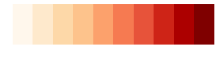

```python
plt.axis('off')
a = plt.imshow([[i for i in range(0,10)],[i for i in range(0,10)]], cmap = "OrRd")
```

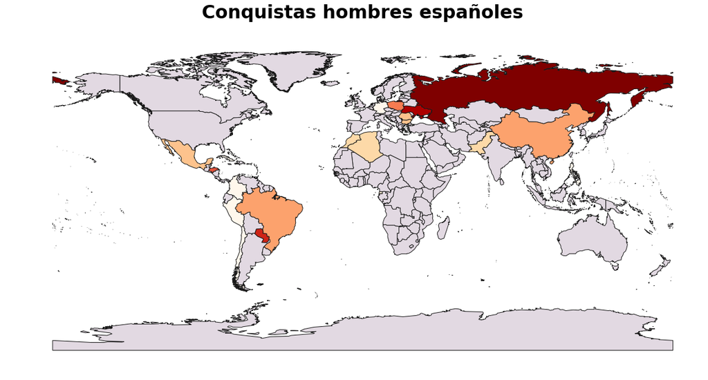

```python
top_españoles = top_matriz(matriz_sexo_diferencial, top = 21, padres ='ESP', funcion_values ='delta%num', sty = 'off')
plot_mapa(top_españoles.set_index("madre")["values"],'Conquistas hombres españoles', trato_na = 'null', colormap = "OrRd")
```

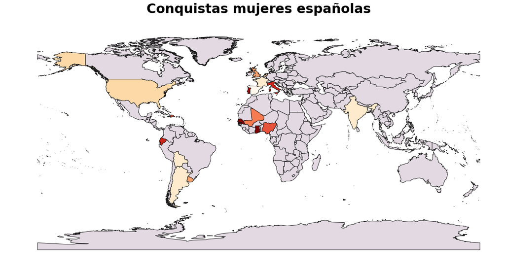

```python
top_españolas = top_matriz(matriz_sexo_diferencial, top = 19, madres ='ESP', funcion_values ='delta%num', sty = 'off')
plot_mapa(top_españolas.set_index("padre")["values"], 'Conquistas mujeres españolas', trato_na = 'null', colormap = "OrRd")
```

[IV] Fidelidad Nacional

### Normalización Matriz por Pareja

```python
def get_matrices_pareja_normal(matrices):

    matrices_pareja_normal = {}

    for key in list(DFs.keys()):

        # normalizar matriz por pareja
        matrices_pareja_normal[key] = matrices[key].astype('float64')
        for i in matrices[key].index:
            total_mujeres = matrices[key].loc[i,:].sum()
            for j in matrices[key].columns:
                total_hombres = matrices[key].loc[:,j].sum()
                resto = total_hombres - total_mujeres
                hijos_potenciales = (total_mujeres+total_hombres-resto)/2
                matrices_pareja_normal[key].loc[i,j]=matrices[key].loc[i,j]/hijos_potenciales

    return(matrices_pareja_normal)
```

```python
matrices_pareja_normal = get_matrices_pareja_normal(matrices)
```

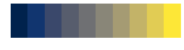

```python
plt.axis('off')
a = plt.imshow([[i for i in range(0,10)],[i for i in range(0,10)]], cmap = colormap)
```

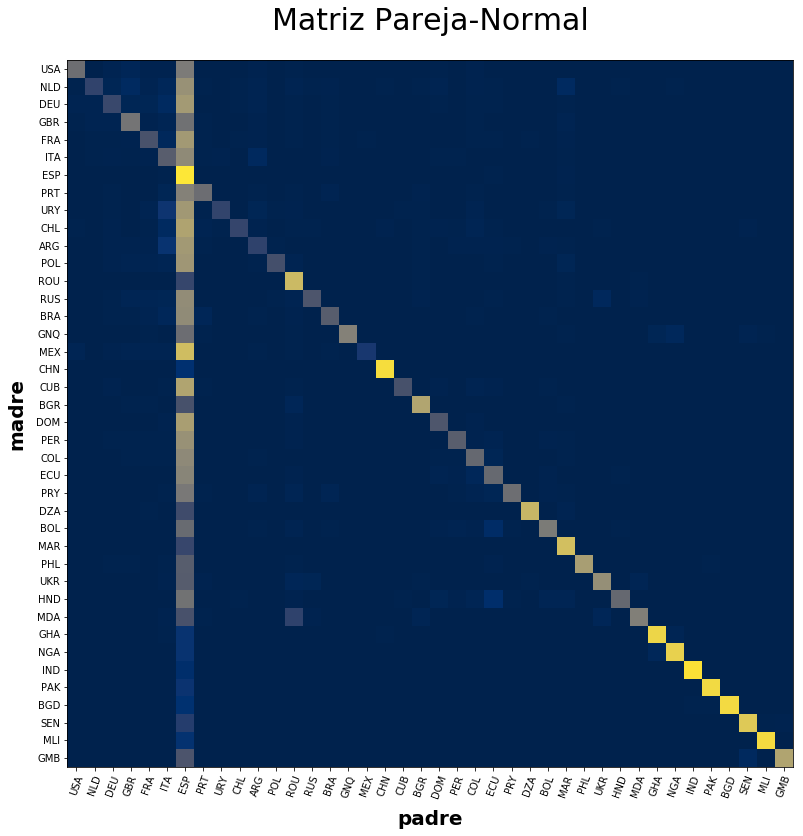

```python
plot_matriz(matrices_pareja_normal[año], 'Matriz Pareja-Normal', False, 1, False)
```

En esta matriz representamos el número de niños para cada combinacion nacional de padres y madres, en relación al número de hijos que tendrían si todos naciesen de esa combinación. Nótese el hecho importante de que en esta ocasión (al contrario que en el análisis porvincial de una entrada anterior), no hemos aplicado ningún suavizado logarítmico. Es decir: la asimetría que vemos entre las relaciones de los hombres españoles con extranjeras (mucho mayores) y las de las mujeres españolas con extranjeros (mucho menores), no es producto de ninguna manipulación matemática.

```python
def get_diagonal(matriz, ordenar = True):
    diagonal = []
    for i in range(0,matriz.shape[0]):
        diagonal.append(matriz.iloc[i,i])
    diagonal = pandas.Series(diagonal,list(matriz.index))
    if ordenar == True:
        diagonal = diagonal.sort_values(ascending = False)
    return(diagonal)
```

```python
def top_serie(serie, top = 10, que = 'max', x = 'values', funcion_values = lambda x : round(x, 2), c = ''):
    df = pandas.DataFrame({'País': serie.index , x: serie}).sort_values([x], ascending = (que == 'min'))
    df.index = [str(i + 1) + 'º' for i in df.reset_index().index]
    if isinstance(funcion_values, str):
        if funcion_values == 'delta%':
            funcion_values = lambda x : '+ ' + str(round((x-1)*100,2)) + ' %'
        elif funcion_values == 'delta':
            funcion_values = lambda x : '+ ' + str(round(x,2))
        elif funcion_values == '%':
            funcion_values = lambda x : str(round(x*100,2)) + ' %'
    df[x] = df[x].apply(funcion_values)
    df.name= "frre"
    return(df.head(top).style.set_caption(c))
```

```python
fidelidad = get_diagonal(matrices_pareja_normal[año])
display(top_serie(fidelidad, x = 'Fidelidad', funcion_values = '%', c = 'Top 10 mayor Fidelidad Nacional'))
display(top_serie(fidelidad, que = 'min', x = 'Fidelidad', funcion_values = '%', c = 'Top 10 menor Fidelidad Nacional'))
```

Top 10 mayor Fidelidad Nacional

|  | País | Fidelidad |
| --- | --- | --- |
| 1º | ESP | 94.94 % |
| 2º | IND | 92.92 % |
| 3º | CHN | 91.26 % |
| 4º | MLI | 90.83 % |
| 5º | BGD | 90.29 % |
| 6º | PAK | 89.92 % |
| 7º | GHA | 88.3 % |
| 8º | NGA | 86.55 % |
| 9º | SEN | 83.1 % |
| 10º | MAR | 79.32 % |

Top 10 menor Fidelidad Nacional

|  | País | Fidelidad |
| --- | --- | --- |
| 1º | MEX | 11.85 % |
| 2º | ARG | 17.35 % |
| 3º | NLD | 17.84 % |
| 4º | URY | 18.18 % |
| 5º | CHL | 19.25 % |
| 6º | DEU | 20.69 % |
| 7º | POL | 24.41 % |
| 8º | CUB | 25.29 % |
| 9º | FRA | 25.98 % |
| 10º | RUS | 27.64 % |

Los más "fieles" a su nacionalidad a la hora de elegir padre/madre para sus hijos son, en primer lugar, los españoles, algo natural ya que estamos en España; pero a no poca distancia les siguen en el podio los Indios y los Chinos, seguidos por otras nacionalidades también con porcentajes de fidelidad muy altos. Estas son, por orden: Mali, Bangladesh, Pakistán, Ghana, Nigeria, Senegal y Marruecos.

El top 3 de las nacionalidades más "infieles" en este sentido lo forman México, Argentina y los Países Bajos. Les siguen Uruguay, Chile, Alemania, Polonia, Cuba, Francia y Rusia.

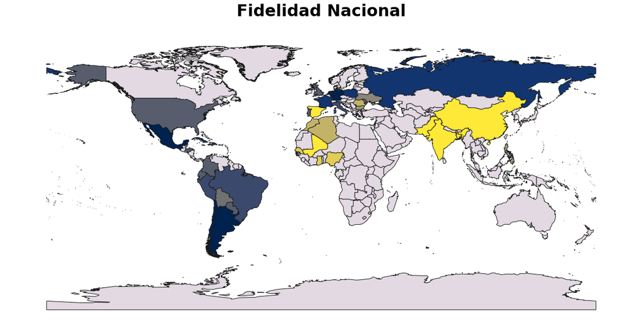

```python
_ = plot_mapa(fidelidad, 'Fidelidad Nacional')
```

En este mapa representamos el porcentaje de niños que nacen con ambos padres de cada país, en relación a los que podrían llegar a nacer si todos se reprodujesen intranacionalmente. El extremo azul indica mínima "fidelidad nacional" entre los hombres y mujeres de ese país que han venido a tener hijos a España, mientras que el extremo amarillo es de máxima "fidelidad nacional". El color gris indica ausencia de datos.

[V] El Turismo Sexual en España, por Sexos

En el apartado anterior vimos que menos del 12% de los mexicanos en España tienen hijos con otro mexicano del sexo puesto.

¿Con quienes tienen hijos los mexicanos y las mexicanas en España? ¿y la gente de otras nacionalidades?

En este aparatado vamos a analizarlo.

```python
def get_matrices_madre_normal(matrices):

    matrices_madre_normal = {}

    for key in list(DFs.keys()):

        # normalizar matriz por madre
        matrices_madre_normal[key] = matrices[key].astype('float64')
        for i in matrices[key].index:
            total = matrices[key].loc[i,:].sum()
            for j in matrices[key].columns:
                matrices_madre_normal[key].loc[i,j] = matrices[key].loc[i,j]/total

    return(matrices_madre_normal)

def get_matrices_padre_normal(matrices):

    matrices_padre_normal = {}

    for key in list(DFs.keys()):

        # normalizar matriz por padre
        matrices_padre_normal[key] = matrices[key].astype('float64')
        for j in matrices[key].columns:
            total = matrices[key].loc[:,j].sum()
            for i in matrices[key].index:
                matrices_padre_normal[key].loc[i,j] = matrices[key].loc[i,j]/total

    return(matrices_padre_normal)
```

```python
matrices_madre_normal = get_matrices_madre_normal(matrices)
matrices_padre_normal = get_matrices_padre_normal(matrices)
```

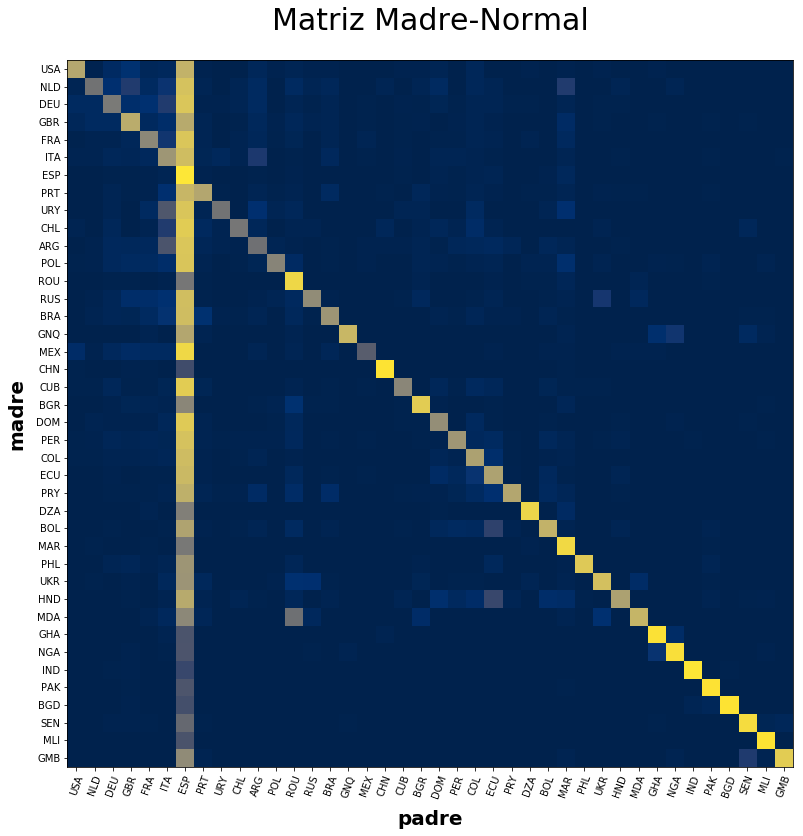

```python
plot_matriz(matrices_madre_normal[año], 'Matriz Madre-Normal', True, 6, False)
```

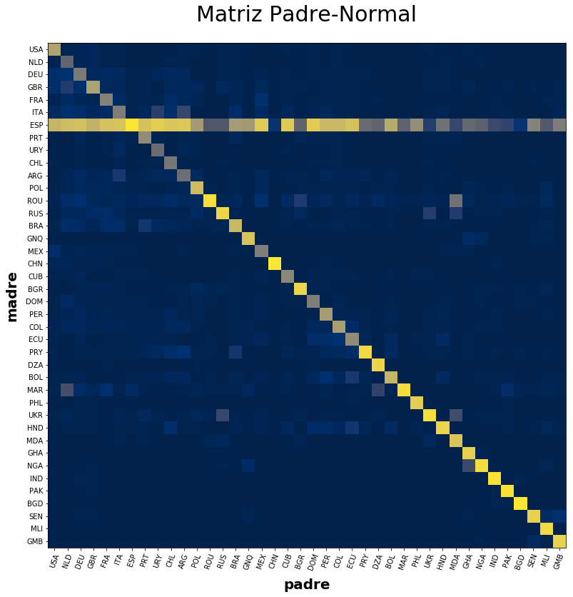

```python
plot_matriz(matrices_padre_normal[año], 'Matriz Padre-Normal', True, 6, False)
```

```python
c = 'Porcentaje de hijos que las mexicanas en España tienen con hombres mexicanos y de otros países'
guadalajareños = top_matriz(matrices_madre_normal[año], x = '%', madres = 'MEX', funcion_values  = '%', c = c )
display(guadalajareños)
c = 'Porcentaje de hijos que los mexicanos en España tienen con mujeres mexicanas y de otros países'
guadalajareñas = top_matriz(matrices_padre_normal[año], x = '%', padres = 'MEX', funcion_values  = '%', c = c )
display(guadalajareñas)
```

Porcentaje de hijos que las mexicanas en España tienen con hombres mexicanos y de otros países

|  | madre | padre | % |
| --- | --- | --- | --- |
| 1º | MEX | ESP | 78.44 % |
| 2º | MEX | MEX | 11.85 % |
| 3º | MEX | USA | 1.66 % |
| 4º | MEX | GBR | 1.42 % |
| 5º | MEX | FRA | 1.18 % |
| 6º | MEX | ITA | 1.18 % |
| 7º | MEX | DEU | 0.95 % |
| 8º | MEX | BRA | 0.71 % |
| 9º | MEX | ARG | 0.47 % |
| 10º | MEX | ROU | 0.47 % |

Porcentaje de hijos que los mexicanos en España tienen con mujeres mexicanas y de otros países

|  | madre | padre | % |
| --- | --- | --- | --- |
| 1º | ESP | MEX | 65.02 % |
| 2º | MEX | MEX | 22.42 % |
| 3º | FRA | MEX | 2.24 % |
| 4º | ROU | MEX | 2.24 % |
| 5º | ITA | MEX | 1.35 % |
| 6º | GBR | MEX | 0.9 % |
| 7º | ECU | MEX | 0.9 % |
| 8º | ARG | MEX | 0.9 % |
| 9º | POL | MEX | 0.9 % |
| 10º | DOM | MEX | 0.45 % |

```python
def plot_filas(filas, labels, titulo = '', sl = False, tsl = 1):
    m = len(filas)
    prov = list(filas[0].index)
    if len(prov) == 1:
        prov = list(filas[0].transpose().index)
    n = len(prov)

    fig, ax = plt.subplots(m, 1, figsize=(30, 2), squeeze =True)

    ax[0].set_title(titulo, fontdict = {'fontsize': 30,'fontweight':700}, pad =30)

    for i in range(0,m):
        if sl == True:
            for time in range(0,tsl):
                filas[i] = filas[i].applymap(lambda celda : math.log(max(0,celda) + 1))
        _ = ax[i].set_yticklabels([])
        _ = ax[i].imshow(filas[i], aspect='auto',  cmap = colormap)
        _ = ax[i].set_xticks(np.arange(n))
        _ = ax[i].set_ylabel(labels[i],fontweight=1000,fontsize=50, labelpad = 30, rotation = 0)
        if i == m - 1:
            _ = ax[i].set_xticklabels(prov, rotation=80, fontdict = {'fontsize': 20,'fontweight':700})
        else:
            _ = ax[i].set_xticklabels([])
```

```python
def plot_sexos_prov(provincia,en='',sl=True,tsl=160):
    fila_madre = matrices_madre_normal[año].loc[[provincia]]
    fila_padre = matrices_padre_normal[año].transpose().loc[[provincia]]
    if en != '':
        en = ' en ' + en + ' '
    tit = 'Parejas Reproductivas de las mujeres y los hombres de '+ provincia + en + ', por país'
    plot_filas([fila_madre,fila_padre],['♀','♂'],tit,sl,tsl)
```

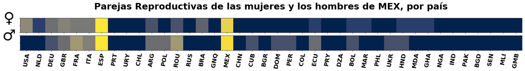

```python
plot_sexos_prov('MEX')
```

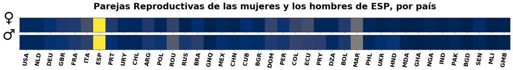

```python
plot_sexos_prov('ESP')
```

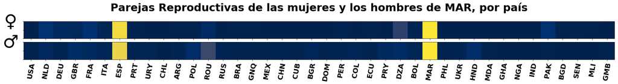

```python
plot_sexos_prov('MAR')
```

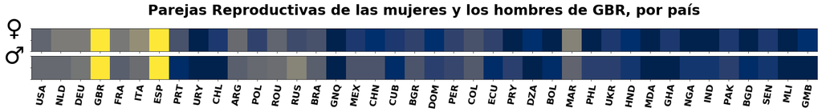

```python
plot_sexos_prov('GBR')
```

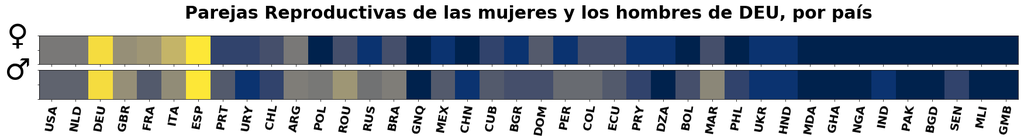

```python
plot_sexos_prov('DEU')
```

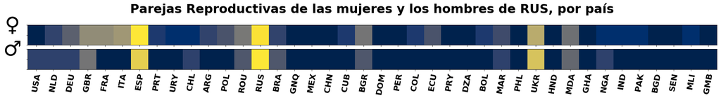

```python
plot_sexos_prov('RUS')
```